# Análise da inovação e Desempenho de MPEs - Programa ALI/Sebrae

# Resumo

Esse projeto apresenta uma análise estatística de dados de Micro e Pequenas Empresas (MPEs) participantes do Programa ALI (Agentes Locais de Inovação), uma iniciativa do Sebrae voltada ao acompanhamento e busca por inovação empresarial. O [Programa ALI](https://sebrae.com.br/subsites/ali) é uma iniciativa do Sebrae com o intuito de acompanhar gratuitamente MPEs, e com os dados obtidos é possível mapear a situação atual do mercado brasileiro, acompanhar as empresas, identificar pontos de melhoria e incentivar práticas de inovação e transformação digital, a fim de contribuir para a produtividade e desempenho dos negócios.

O projeto em questão abrange estudos sobre empresas do ramo de Construção Civil de todos os estados brasileiros, e está inserido em uma pesquisa nas áreas de construção civil e empreendedorismo, cujos dados utilizados foram obtidos pelo Programa ALI entre 2023 e 2024.

Para chegar nos resultados mostrados aqui, fiz durante meses análises estatísticas de uma base de dados com cerca de 100 mil empresas. A partir dessa base, foram aplicados filtros para selecionar as empresas da cadeia da construção civil em todos os estados brasileiros, e então fiz uma análise exploratória com o fim de fazer as correções necessárias e criar novas variáveis com base nas existentes que seriam úteis posteriormente. Minha atuação neste projeto envolveu etapas da análise dos dados desde análise exploratória, criação e transformação de variáveis, estatística descritiva, visualização e dados e inferência. No decorrer do projeto, foram analisadas diversas hipóteses com relação à produtividade, faturamento, inovação e transformação digital, fazendo comparaçãoes também entre setores e estados/regiões.

Para isso, utilizei principalmente R e Excel. O R foi utilizado para programação, manipulação e transformação dos dados, criação de variáveis e aplicação de métodos estatísticos para testar hipóteses. O Excel foi utilizado para exploração, organização e visualização de dados, incluindo tabelas, gráficos e mapas interativos. Para a parte de visualização de dados, Excel e R foram ambos utilizados.

## Sobre o projeto

O projeto de Iniciação Científica do que faço parte e no qual este trabalho está inserido possui um escopo mais abrangente quanto à análise das empresas, de modo que foram feitas também análises de outros “radares” de desempenho, como gestão de marketing, práticas sustentáveis, entre outros.

Para construir este projeto/portfólio, selecionei apenas um “recorte” dos resultados, focando nas análises de inovação, transformação digital, produtividade e faturamento, a fim de mostrar métodos, análises, resultados e insights interessantes sem um texto tão extenso.

Portanto, o que é exibido aqui não representa a totalidade do estudo feito nesses últimos meses, mas sim um conjunto de métodos e resultados específicos selecionados para representar a pesquisa.

# Objetivos

O intuito deste projeto (portfólio) é utilizar técnicas e métodos de estatística descritiva e inferencial para estuda, no recorte do estudo, as relações entre transformação digital, inovação, produtividade e faturamento das empresas analisadas, avaliando também as nuances entre setores, estados e regiões.

## Principais questões a serem estudadas

- Como variou a produtivdade e o faturamento das empresas analisas?
- Há associação entre evolução da produtividade e faturamento?
- Como a transformação digital se relaciona com a produtividade das empresas?
- Como se comportam os indicadores de inovação, produtividade e faturamento entre os estados e regiões?

# Metodologia

## Seleção e preparação dos dados

Antes de chegar em qualquer conclusão, foram necessárias algumas etapas essenciais, são elas:

Base de dados original -> seleção das empresas de interesse -> aplicação de filtros e tratamento de outliers -> criação de variáveis úteis -> análise exploratória -> análises estatísticas e testes das hipóteses -> resultados.

Inicialmente, a base de dados do Programa ALI incluía inúmeras empresas de vários segmentos, além de empresas que não concluíram o programa. Desse modo, para obter-se apenas os dados que seriam utilizados na pesquisa, foram realizados filtros por CNAEs, Subsegmentos, entre outros. Também foram removidas as empresas que não foram do início ao fim do programa.

Para o tratamento de outliers, foi utilizado o método da amplitude interquartil (IQR), que faz uso da diferença entre o primeiro e terceiro quartis (Q3 - Q1) para estabelecer um limite, de modo que valores acima e abaixo de 3$\times$IQR foram considerados valores extremos e foram removidos. Em geral, é utilizado um limite de 1.5$\times$IQR, mas especialmente em bases de dados extensas, esse critério pode produzir uma quantidade considerável de pontos que, na verdade, não deveriam ser removidos.

Após as devidas correções e tratamentos dos dados, obteve-se uma base de 7202 empresas.

## Construção das variáveis

A base de dados original já trouxe consigo inúmeras variáveis, desde identificação das empresas e locais das mesmas, até os indicadores de inovação, produtividade, entre outros. Mas para uma análise estatística mais profunda, foi necessário criar outras variáveis a partir daquelas já existentes, como por exemplo a *variação da produtividade*, criada a partir da diferença entre a produtividade avaliada ao final do programa e a produtividade avaliada no início do programa.

## Análise exploratória

Após a preparação dos dados, foi feita uma investigação inicial a fim de entender as distribuições das variáveis, verificar a presença ou não de normalidade, identificar possíveis problemas e auxiliar a orientar as decisões e análises posteriores. Foram feitos desde alguns gráficos simples como boxplots, até testes de aderência para verificar a existência de normalidade, o que se provou não haver no casos destes dados.

## Análises estatísticas e testes de hipóteses

Após verificar nos dados que os pressupostos de normalidade não foram atingidos, foi necessário recorrer a métodos não paramétricos, especialmente o teste de Wilcoxon, que é uma alternativa não paramétrica ao teste-t pareado, e o teste de Kruskal-Wallis, sendo uma boa alternativa à ANOVA (Analysis of Variance) quando não há normalidade.

Para verificar diferenças entre indicadores ao início e fim do Programa ALI, foi utilizado o teste pareado Wilcoxon signed-rank.

O teste de Wilcoxon avaliada $D_i = Y_i - X_i$, onde $D_i$ é a diferença entre o indicador ao fim do programa $(Y_i)$ e o indicador no começo do programa $(X_i)$, de modo que $D_i$ representa a mudança observada entre os dois momentos. Em seguida, são calculados os valores absolutos de $D_i$ e descarta-se os pares onde a diferença absoluta é igual a zero, então ordena-se os valores e atribui-se postos (ranks) a eles. Com isso, é calculada a estatística $W^+$, que representa a soma dos postos com diferenças positivas:

$W^+ = \sum_{D_i>0} R_i$

Quando era esperado observar-se um aumento dos indicadores, foi utilizado o teste de hipóteses unilateral à direita, sendo as hipóteses:

$$H_0: \mu_D \le 0$$

$$H_1: \mu_D > 0$$

em que $\mu_D$ representa o parâmetro de locação das diferenças

Caso o previsto fosse apenas alguma alteração, sem uma direção específica, foi aplicado um teste bilateral, com as seguintes hipóteses:

$$H_0: \mu_D = 0$$

$$H_1: \mu_D \ne 0$$

Em todos os testes, foi adotado um nível de significância de 5%, de modo que quando foi obtido um valor-p de $p \le 0,05$, isso foi considerado como evidência estatística suficiente para rejeitar a hipótese nula. Além disso, foi avaliada tambéma a variação percentual mediana do indicador, de modo a ter uma análise segura e uma interpretação mais completa.

Nos casos em que se desejava verificar se um indicador variava de acordo com o grupo ao qual ele pertencia, foi utilizado o teste de Kruskal-Wallis.

O teste de Kruskal-Wallis ordena as observações em postos (ranks) e substitui os valores originais por esses postos, e com isso calcula-se a estatística $H$:

$$H = \frac{12}{N(N + 1)} \sum_{j=1}^{k}
\frac{R_j^2}{n_j} - 3(N + 1)$$

onde $N$ é o total de observações, $n_j$ o número de empresas no grupo $j$ e $R_j$ é a soma dos postos atribuídos às observações do grupo. Caso haja empates, a estatística $H$ é ajustada, de modo que temos $H^*$:

$$H^* = \frac{H}{C}$$

$$C = 1 - \frac{\sum_{i=1}^{m} (t_i^3 -
t_i)}{N^3 - N}$$

em que $m$ é a quantidade de grupos com mesmos postos e $t_i$ o número de observações associadas ao i-ésimo grupo de empate, de modo que o próprio software R faz esse ajuste automaticamente quando necessário.

As hipóteses testadas por Kuskal-Wallis são:

$H_0: F_1 = F_2 = ... = F_k$

$H_1: \text{ existe um } j \ne i \text{ tal que } F_j \ne F_i$

onde $F_j$ representa a distribuição indicador analisado no grupo $j$.

O nível de significância adotado é de 5%, de modo que valores-p de $p \le 0,05$ indicam evidência estatística suficiente para rejeitar a hipótese nula.

Em casos de rejeitar a hipótese nula, foi feito também o teste de comparações múltiplas pairwise Wilcoxon rank-sum test, que compara os grupos par a par a fim de descobrir quais grupos específicos tem diferença significativa entre si. Mas em casos de haver uma quantidade muito grande de comparações, o erro do tipo I (rejeitar uma hipótese quando ela é verdadeira) se torna muito mais provável, e para evitar isso foi aplicada a correção de Bonferroni aos p-valores. O método consiste em multiplicar cada valor de $p$ pelo número de comparações feitas $(m)$.

$$m = \frac{k(k-1)}{2}$$

onde $k$ é o número de grupos independentes comparados.

# Resultados

As análises a seguir são parte do recorte feito da pesquisa, mostrando resultados de maior relevância acerca da transformação digital, inovação, produtividade e faturamento.

## Produtividade x faturamento

Inicialmente, foi realizado um teste de Wilcoxon usando a linguagem R para comparar o indicador de produtividade no momento inicial com o momento final, e em seguida o mesmo foi feito para o indicador de faturamento, como pode-se ver nos resultados abaixo. Ao nível de significância de 5%, foi verificado que houve aumento tanto na produtividade quanto no faturamento das empresas que participaram do Programa ALI.

Após isso, foi calculada a variação percentual média e mediana de ambos os indicadores, cujos resultados foram plotados no gráfico de barras abaixo, permitindo não só visualizar, mas quantificar de forma clara o aumento dos indicadores.

É evidente que tanto a produtividade quanto o faturamento das empresas cresceram, sugerindo que pode haver um padrão entre ambos os indicadores.

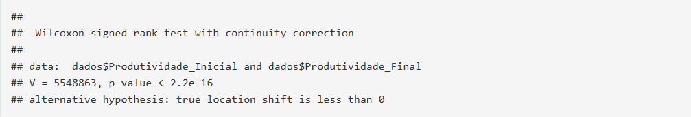

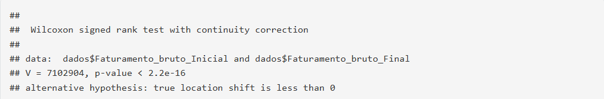

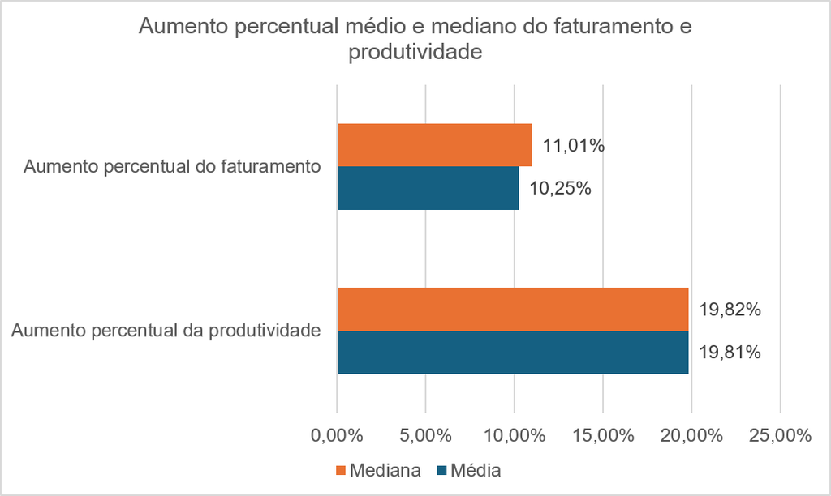

Com isso, surge naturalmente a pergunta “Visto que tanto a produtividade quanto o faturamento aumentaram, existe alguma relação entre eles?”

Para responder essa pergunta, foi feito um gráfico de dispersão que compara a variação da produtividade com a variação do faturamento.

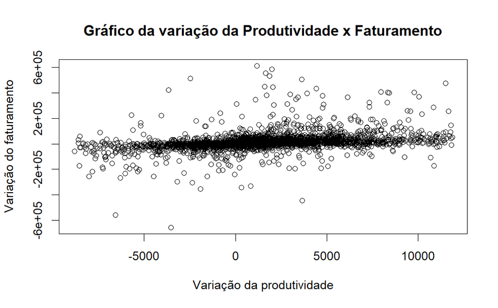

Também foi feito usada a correlação de Spearman, ideal para casos onde não há pressuposição de normalidade, chegando a um coeficiente de $\rho = 0,519$, que é uma correlação moderada, indicando que as empresas com maior aumento da produtividade tendem a apresentar também um maior crescimento do faturamento.

No entanto, é importante ressaltar que isso não implica em causa e efeito, já que há outros fatores que podem estar envolvidos no aumento dos indicadores.

## Transformação digital x Produtividade

Para avaliar o impacto da transformação digital na produtividade, foi utilizado o coeficiente correlação de Spearman, cujo resultado foi $\rho = 0,047$, indicando uma correlação extremamente fraca, mas ainda positiva. Esse valor indica que não há evidência de que, ao aumentar a transformação digital, a empresa também tenha um aumento na produtividade.

No entanto, eu resolvi colocar esse resultado porque à primeira vista ele parece ruim, mas analisando gráficos com os resultados das empresas, o aumento na transformação digital parece ser acompanhado por um crescimento também na produtividade.

No gráfico abaixo, temos o aumento percentual mediano da produtividade no setor de Serviços, para cada 1 ponto de aumento no indicador de transformação digital, e vemos que as empresas tiveram maior aumento de produtividade conforme a transformação digital cresceu, com exceção de quando houve 4 pontos de aumento. Além disso, o fato de haver aumento também com 0 pontos de aumento na transformação digital é um indício de que há outras variáveis que também influenciam o aumento de produtividade.

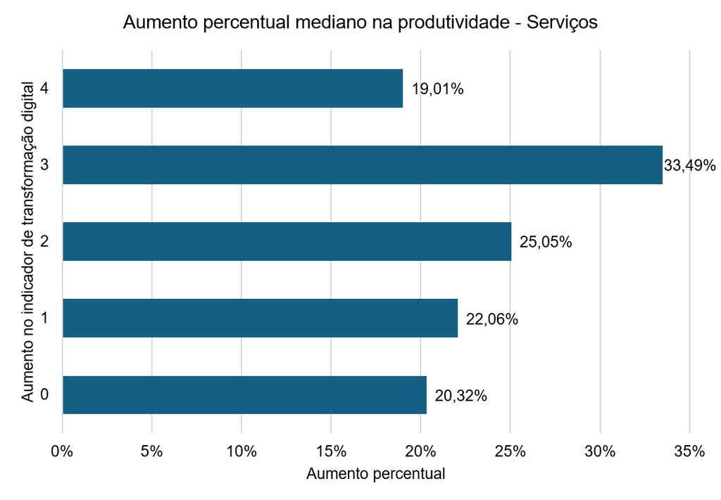

Enquanto no próximo gráfico, vemos o mesmo cálculo, porém para o setor de Construção Civil. Diferentemente do setor de serviços, aqui a produtividade decai do nível 0 ao 1, e depois voltar a subir novamente, e mais uma vez decresce quando o aumento foi de 4 pontos. Uma possível explicação para o comportamento irregular no setor de Construção Civil é que a forma de produção e organização do trabalho, e os meios pelos quais o conhecimento da área é disseminado podem ser diferentes de outros setores, possivelmente dificultando a adesão a novas tecnologias e a inovação digital. No entanto, esse é um ponto que não foi diretamente testado, portanto é importante citar que essa questão é uma possibilidade a ser investigada em estudos futuros.

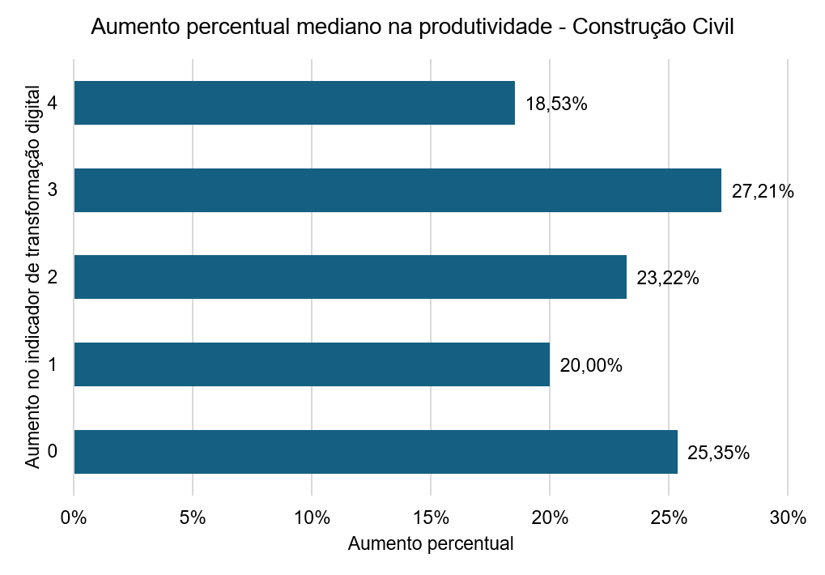

Por fim, a transformação digital foi dividida em duas partes: *Alto crescimento*, para as empresas que tiveram um aumento do indicador acima da mediana, e *Outros*, para as empresas que tiveram um aumento abaixo da mediana do indicador. Com isso, tem-se a tabela abaixo, onde podemos ver que o grupo de *Alto crescimento* teve maior aumento médio e mediana de produtividade, mesmo esse grupo tendo 5 vezes menos empresas do que o grupo *Outros*, evidenciando que quanto maior a evolução na transformação digital, em geral, maior tende a ser o aumento de produtividade da empresa que, por sua vez, vimos que é seguido por um crescimento também do faturamento.

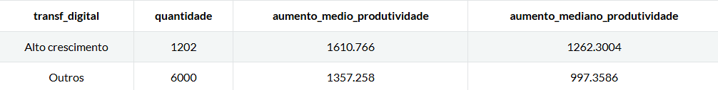

## Inovação x Produtividade x Faturamento

Neste caso, o objetivo foi verificar se a inovação, por si só, impacta na produtividade e no faturamento. Para isso, o radar de inovação ao fim do programa foi dividido também em dois grupos: *Alta*, para empresas que tiveram pontuação de inovação final acima da mediana, e *Outros* para as empresas que tiveram inovação final abaixo da mediana. Com isso, chegou-se à tabela abaixo, onde podemos ver que o grupo com maior inovação final obteve maior aumento médio e mediano de produtividade.

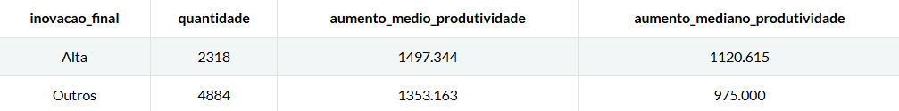

A mesma análise foi feita com relação ao faturamento, onde o resultado foi o mesmo: o grupo com maior inovação final teve maior aumento médio e mediano do faturamento.

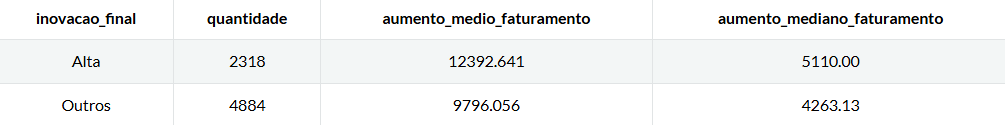

Com isso, podemos ver que conforme uma empresa inova, tende a obter um aumento de produtividade e faturamento. Contudo, foi feita uma análise adicional para chegar-se a uma conclusão mais assertiva.

Utilizando os mesmos dois grupos de inovação final, foi calculado o aumento percentual médio e mediano da produtividade e do faturamento, e o resultado obtido pode ser visto na tabela abaixo.

De acordo com os resultados anteriores, talvez pudéssemos pensar “É esperado que a produtividade e o faturamento das empresas com maior nível de inovação final aumente consideravelmente mais do que no caso das empresas com menor nível do indicador”, mas ao analisar os números, não é isso que se observa.

Em geral, houve um aumento percentual maior no caso de maior inovação final, mas não foi uma diferença exorbitante, o que pode parecer um resultado negativo à primeira vista, mas isso mostra que mesmo empresas que inovaram pouco obtiveram um bom aumento de produtividade e faturamento, evidenciando que a inovação pode estar relacionada a uma melhoria nos dois indicadores nas empresas.

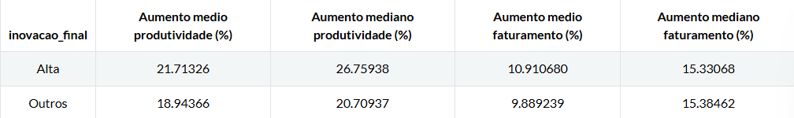

# Estado e Região

Para melhor compreender como os indicadores variam de acordo com a localização geográfica, foram feitos alguns estudos envolvendo os radares de produtividade e faturamento.

## Análise por estado

A princípio, foi realizado um teste de Kruskal-Wallis que verificou, a um nível de significância de 5%, que há diferença estatisticamente significativa entre os estados quanto à **produtividade no início do programa**.

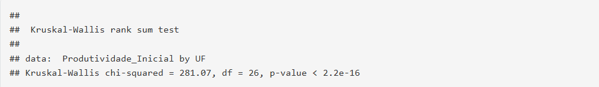

Em seguida, podemos visualizar a distribuição dos estados quanto à produtividade inicial no boxplot abaixo. Nele, podemos ver que o estado que mais se destacava ao início do programa era Tocatins. Além disso, vê-se, pelos pontos mais distantes, que mesmo tratando os outliers da base, ainda há empresas que se destacam de forma excepcional e relação às outras.

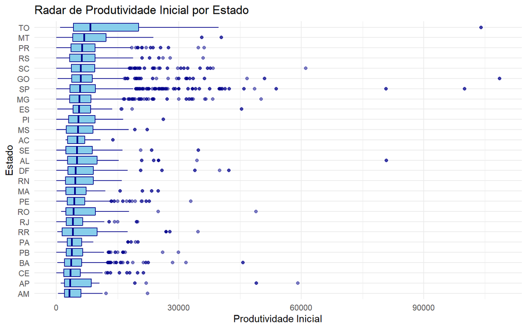

No entanto, é interessante notar que, ao analisar o mesmo gráfico com as empresas plotadas, fica nítido que Tocantins tem um número muito menor de empresas (46) em comparação, por exemplo, ao estado de São Paulo (1823). Isso mostra que Tocantins concentra poucas empresas, mas que sozinhas já possuiam inicialmente um desempenho alto o bastante para superar o estado de São Paulo, que é reconhecido por ser o principal centro econômico que país.

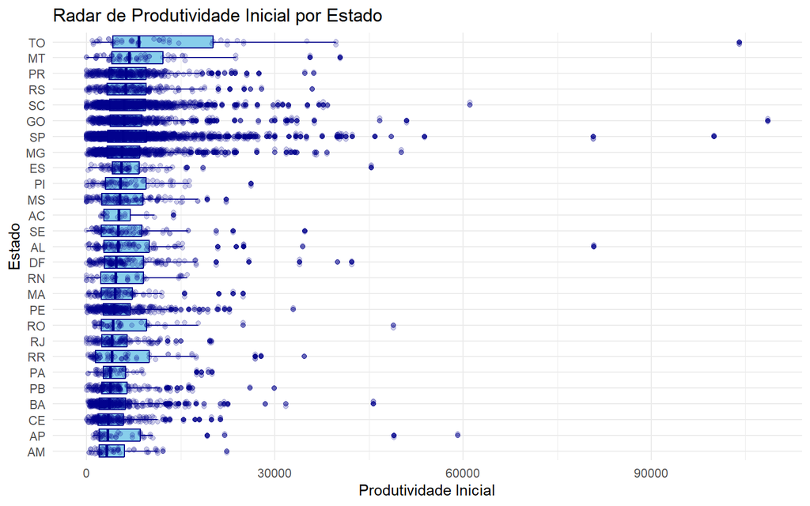

No gráfico de barras abaixo, podemos ver claramente a magnitude, em média, da diferença entre os 10 principais estados em produtividade inicial.

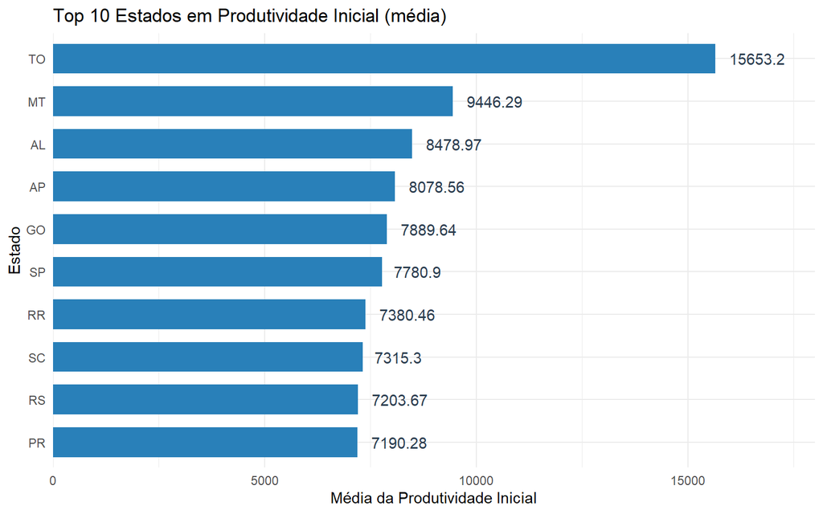

Enquanto isso, ao analisar a **variação da produtividade**, isto é, quanto cada estado evoluiu ao longo do Programa ALI, temos novamente uma diferença significativa entre os estados apontada pelo teste de Kruskal-Wallis.

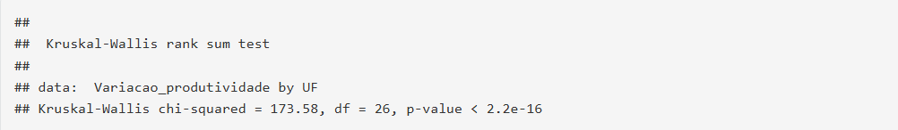

No boxplot abaixo, podemos ver que o estado que mais cresceu em produtividade durante o programa foi Rondônia. Além disso, pode-se observar pela linha vertical dentro de cada caixa (mediana), que todos os estados ficarama com sua mediana acima de zero, ou seja, pelo menos metade das empresas cresceram em produtividade.

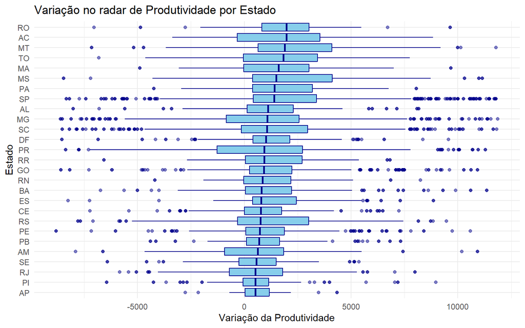

Já no boxplot abaixo, podemos ver que assim como no caso de produtividade inicial, o estado de Rondônia, que mais se destacou, também possui um número muito pequeno de empresas (48), mostrando que mesmo sendo poucas, elas tiveram um desempenho excepcional que as colocaram acima dos outros estados.

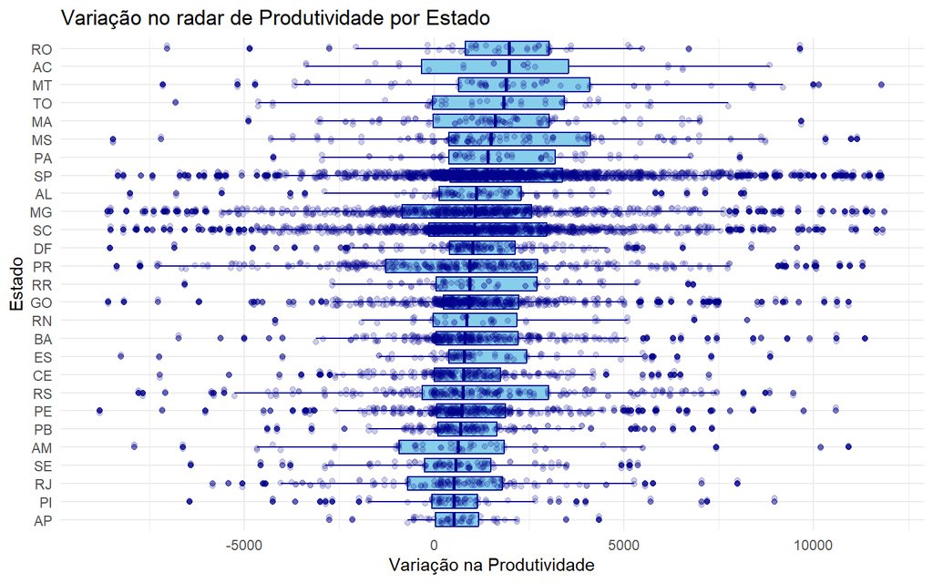

Entretanto, é importante lembrar que quando ordenamos boxplots, como nos gráficos anteriores, o fazemos com base na mediana, enquanto se olharmos pela média a ordem dos estados pode mudar, como é o caso abaixo. Aqui, vemos que SP ficou à frente de TO e RO, diferente dos casos anteriores.

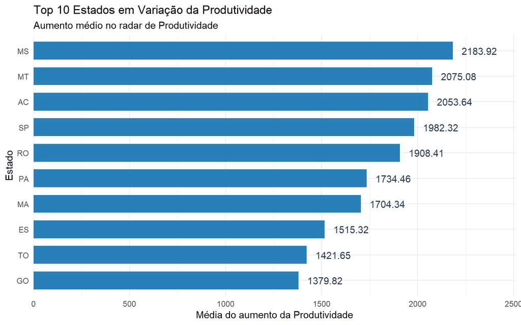

## Análise por região

Quando analisamos a **produtividade inicial** por região, o teste de Kruskal-Wallis também conclui que as regiões têm medidas significativamente diferentes entre si.

Além disso, na tabela abaixo podemos ver a diferença entre as regiões com base na mediana, tendo a região Sul como a mais destacada no nível de produtividade inicial.

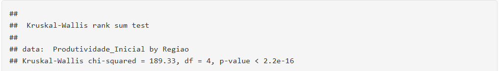

O fato de as pontuações de produtividade parecerem mais estáveis ao se estudar as regiões (efeito de agregação) se deve à Lei dos Grandes Números. Quando trabalhamos com amostras menores (caso dos estados), empresas com desempenhos extremos – para mais ou para menos, tendem a causar um impacto maior, enquanto no caso de amostras maiores (como é com as regiões), a variância tende a diminuir com o aumento do tamanho amostral, causando esse efeito de agregação, que nos mostra números mais “estáveis” e próximos.

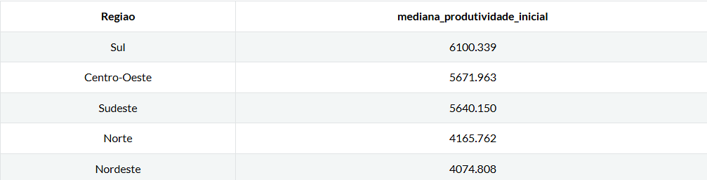

A seguir, também vemos que a região Norte tem muito menos empresas do que as outras regiões, como já era esperado ao ver a quantidade de empresas cadastradas no programa nos estados de TO e RO, anteriormente.

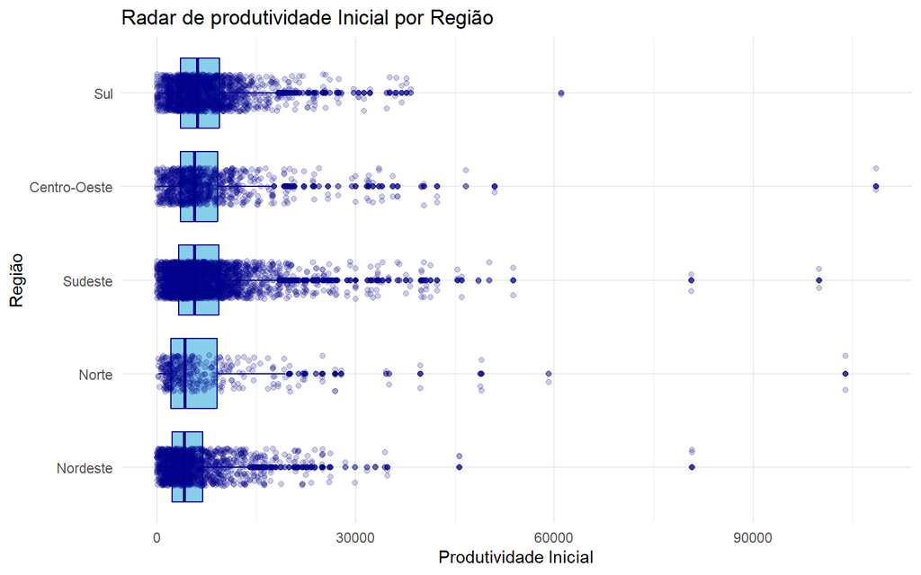

Assim como visto no caso dos estados, ao analisarmos a média, a ordem pode mudar, já que a média é mais sensível a valores extremos, como podemos ver abaixo. Sabemos que a região Norte tem um número muito pequeno de empresas, e vimos também que essas poucas empresas desempenharam muito bem, assim fazendo a média subir e até superar outras regiões com mais empresas e, por isso, um efeito de agregação maior.

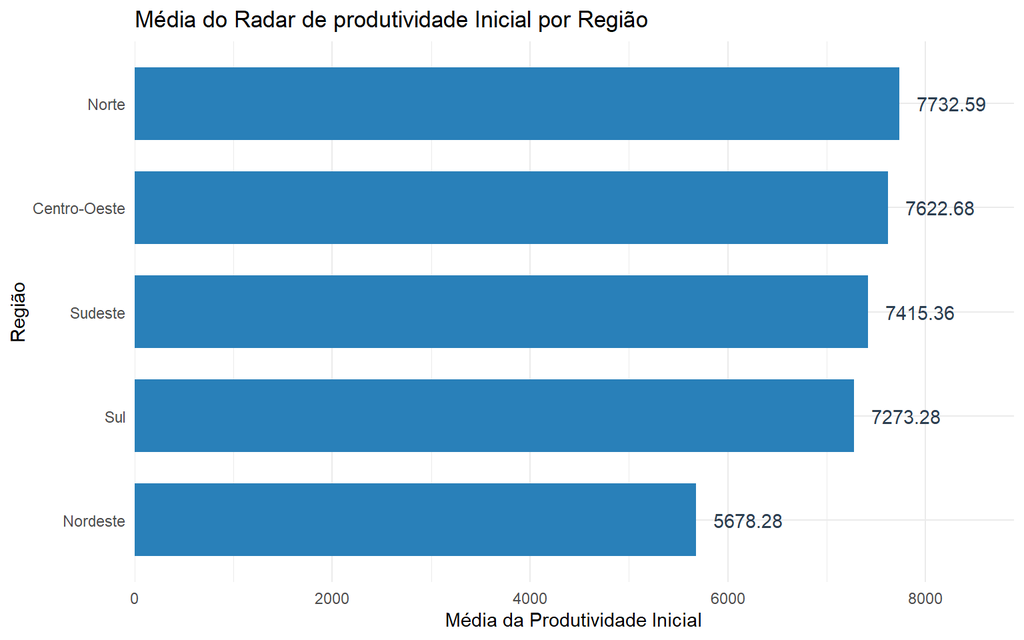

Quando analisamos a **variação da produtividade** das regiões, também é apontada, pelo teste de Kruskal-Wallis ao nível de significância de 5%, uma diferença estatisticamente significativa.

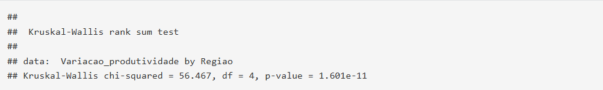

Ao avaliar a variação da produtividade, vemos que a região Sudeste se destacou, enquanto a região Norte, que possui uma produtividade inicial forte, teve uma pontuação menor e quase igual à da região Sul.

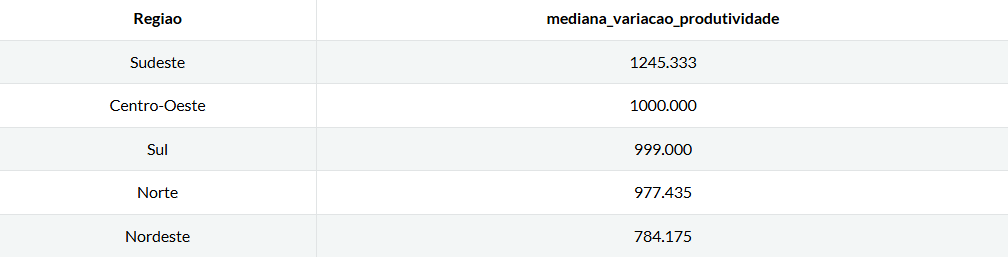

E novamente podemos ver a diferença na quantidade de empresas, sendo que a região Norte possui um número muito menor.

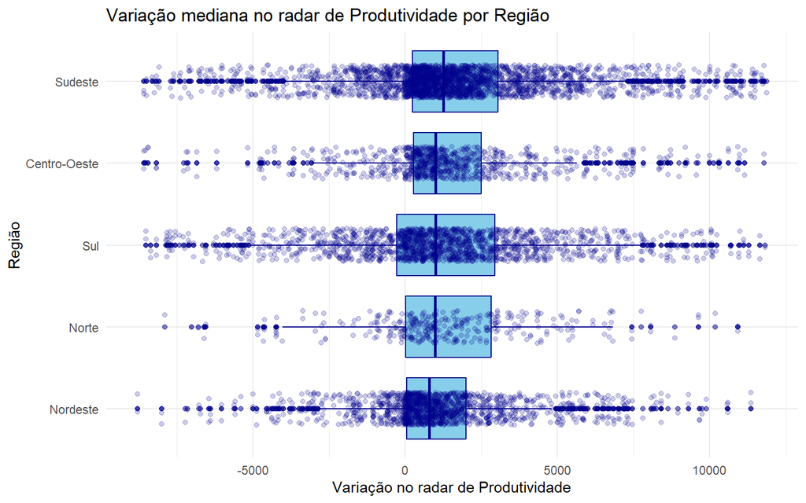

Neste caso, quando avaliamos a variação média, ao invés da mediana, a ordem se mantém quase a mesma, exceto pela região Norte superar a região Sul, com o Sudeste mantendo-se em destaque com a maior evolução de produtividade.

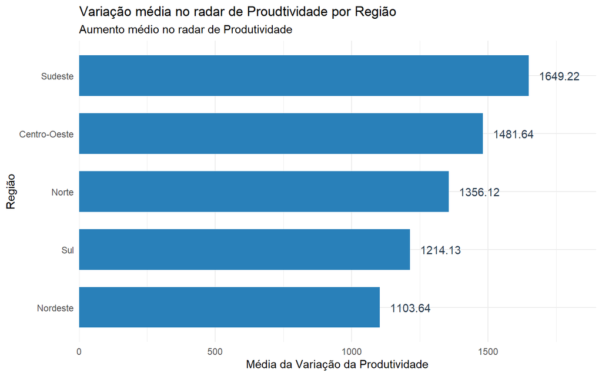

Abaixo, também podemos ver a distribuição do número de empresas por estado no Brasil, de modo que a região Sudeste é a que mais se destaca.

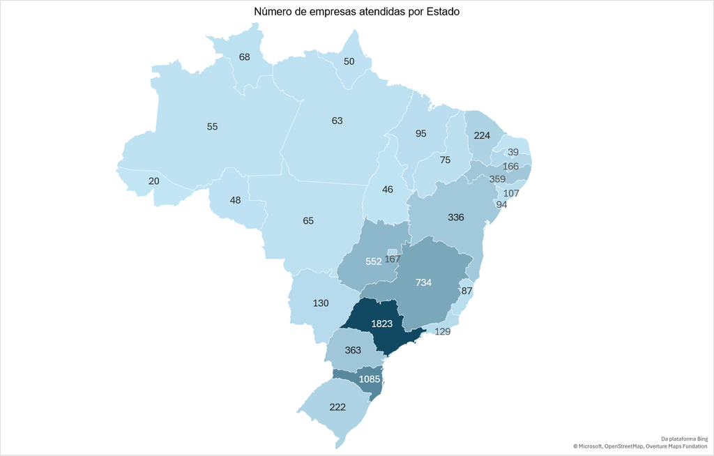

## Onde entra o faturamento?

Ao avaliarmos as regiões com base na produtividade e também o crescimento de faturamento, temos o resultado abaixo.

Aqui, podemos ver que houve um aumento no faturamento em todas as regiões, e que a região Sudeste foi a que mais se destacou, em aumento percentual mediano, na variação da produtividade.

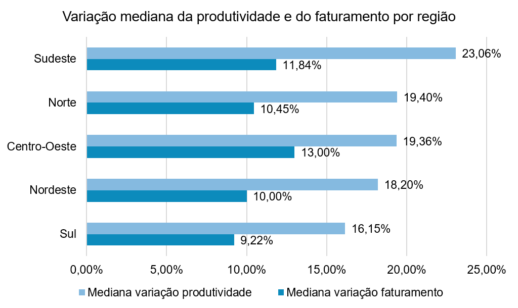

# Principais Insights

As análises realizadas permitiram encontrar resultados valiosos envolvendo inovação, transformação digital, produtividade e faturamento. Mais do que apenas apontar alguma correlação ou possível causa, foi possível observar nuances interessantes e comportamentos diferentes nos indicadores dependendo do contexto.

## Insight 1 — Produtividade e faturamento apresentaram crescimento durante o período analisado

Entre o começo e o fim do acompanhamento, foram observados aumentos estatisticamente significativos na produtividade e no faturamento. Isso foi verificado não só por testes estatísticos, como Wilcoxon, como também ao avaliar a real magnitude do crescimento por meio de percentuais médios e medianos, além de visualizações gráficas que permitem enxergar os resultados de forma mais concisa.

Esse resultado deve ser interpretado como uma evolução entre dois momentos de avaliação distintos no tempo, não como uma evidência isolada de que a participação no Programa ALI tenha causado toda essa evolução, de modo que há diversos outros fatores que podem impactar uma empresa.

## Insight 2 – Há uma associação moderada entre produtividade e faturamento

A evolução da produtividade apresentou uma correlação positiva moderada com a evolução do faturamento $(\rho = 0,519)$, indicando que empresas que apresentaram maiores aumentos de produtividade tendem também a apresentar maiores aumentos de faturamento.

Esse resultado sugere que produtividade e faturamento estão relacionados, mas não podemos tratar essa associação como uma relação causal entre os indicadores, já que outros fatores podem, ao mesmo tempo, influenciar a produtividade e o faturamento.

## Insight 3 – A relação complexa entre transformação digital e produtividade

A correlação entre transformação digital e produtividade foi muito mais fraca do que a observada entre produtividade e faturamento, tendo um coeficiente de correlação de $\rho = 0,047$, o que ainda é uma associação positiva, mas muito fraca.

Entretanto, ao avaliar a magnitude da variação da produtividade das empresas tendo como base a variação da transformação digital, obteve-se um padrão diferente: em geral, quanto mais o indicador de transformação digital crecia, maior se mostrava o indicador da produtividade, avaliando tanto pela média quanto pela mediana. No setor de Serviços, a mediana da variação da produtividade tendeu a aumentar de acordo com a evolução da transformação digital, diferente do setor de Construção Civil, que mostrou uma maior oscilação.

Essa diferença entre uma análise geral e uma análise por grupos mostra a importância de não avaliar uma hipótese apenas com base em um único coeficiente de correlação, mas sim fazer uso de outras formas de visualização de dados para complementar a análise e garantir uma conclusão mais assertiva.

## Insight 5 – O tamanho das amostras afeta as análises por estado e região

A análise por estado mostrou diferenças estatisticamente significativas na produtividade, tanto no início do programa quanto na evolução ao longo do mesmo. Porém, a interpretação deve ser feita de forma cuidadosa, já que alguns estados têm um número de empresas muito distoantes dos demais.

Tocantins, por exemplo, se destacou na produtividade inicial tendo apenas 46 empresas no programa, enquanto São Paulo possuía 1823. Da mesma forma, Rondônia também apresentou a maior mediana no crescimento da produtividade com apenas 48 empresas.

Assim, o fato de um estado estar uma posição alta no ranking de produtividade, não indica necessariamente que a maioria das empresas daquele estado estejam bem representadas.

## Insight 6 – Estados e regiões podem levar a conclusões distintas

Apesar de alguns estados terem se destacado mais, ao avaliar por região os resultados são mais estáveis, devido ao maior número de observações nas amostras. No indicador de produtividade inicial, a região Sul se destacou, enquanto na variação, isto é, na evolução em produtividade ao longo do tempo, o Sudeste foi a principal região.

Isso mostra o cuidado que devemos ter com o nível de agregação das amostras. Enquanto nos estados valores extremos podem influenciar mais fortemente as análises, especialmente envolvendo a média, os estudos com as regiões são menos sensíveis a isso, devido às suas maiores amostras.

# Limitações do estudo

## 1. Associação não implica causalidade

Os dados são de um estudo transversal, isto é, cortes de momentos específicos no tempo, não um estudo contínuo. Além disso, são dados observacionais, portanto as associações entre inovação, transformação digital, produtividade e faturamento não podem ser interpretadas como causalidade. Os resultados observados não podem ser atribuídos exclusivamente ao Programa ALI ou a qualquer dos indicadores, já que eles deveriam ser avaliados isoladamente de forma mais controlada para isso.

## 2. Empresas não concluintes podem ser diferentes

Como foram removidas as empresas que não concluíram o programa, existe a possibilidade de haver um viés de seleção, já que elas podem ser diferentes das empresas que permaneceram no programa em algum aspecto.

## 3. Tratamento de outliers

O método de $3\times IQR$ utilizado para remover outliers de produtividade é um método usualmente adotado na literatura, entretanto ele pode causar também a exclusão de empresas que tiveram resultados reais e relevantes para o estudo. Métodos diferentes poderiam levar a conclusões diferentes, mas não necessariamente há um método específico “perfeito” para o caso.

## 4. Diferença do tamanho amostral entre os estados

Muitos estados possuem um número pequeno de empresas, como RO e TO, enquanto estados como SP possuem um número substancialmente maior. Isso pode levar a estatísticas sensíveis nas amostras menores, e resultados que dizem mais sobre poucas empresas específicas, e não sobre o estado em si.

## 5. Grupos divididos com base na mediana

Em alguns casos, foi feita uma divisão entre dois grupos com base na mediana, o que facilita a comparação entre grupos, mas isso pode acarretar em alguma perda de informação sobre as empresas analisadas.

# Conclusão

Com as análises neste projeto, foi possível investigar relações entre inovação, transformação digital, produtividade e faturamento, de acordo com uma base de dados de empresas participantes do Programa ALI, destacando também diferenças com base na localização geográfica.

Em geral, foi observado um crescimento de produtividade e faturamento entre os momentos inicial e final do programa. A evolução da produtividade também mostrou certa associação com o crescimento do faturamento, de modo que empresas com maior aumento de produtividade em geral tenderam a mostrar maior crescimento do faturamento.

A análise geográfica mostrou um resultado similar: diferenças significativas entre os estados, de modo que alguns se destacavam muito, mas quando o indicador de produtividade foi avaliado com base nas regiões, o resultado foi mais estável e homogêneo.

Esse estudo mostrou que os indicadores não devem ser avaliados isoladamente, mas em conjunto e de acordo com contextos específicos das empresas, já que há muitos fatores que podem influenciar na evolução de uma empresas. O uso de estatística descritiva, visualização de dados e testes estatísticos foi muito útil para revelar padrões que normalmente seria difíceis de se enxergar.

Este projeto foi uma oportunidade muito boa de aplicar os conhecimentos estatísticos que adquiri tanto na faculdade quanto nos meus estudos, tendo a chance de trabalhar com dados de empresas de mundo real, diferentemente dos dados disponibilizados para estudo em aulas na universidade. Pude trabalhar com várias etapas de análise de dados, desde análise exploratória, limpeza de dados, tratamento de outliers, visualização de dados e aplicação de testes estatísticos em um contexto não paramétrico.

Por fim, um dos meus maiores aprendizados foi questionar o que os dados realmente dizem. Aprendi que não devemos apenas confiar completamente em um único resultado, mas complementá-lo e verificar sua veracidade com outros tipos de testes e formas de visualização de dados, de modo que possamos chegar a uma conclusão mais assertiva e garantir a melhor interpretação e análise possível, dessa forma gerando insights valiosos que possam ocasionar mudanças no mundo real.